# Metalyzer Compiler Suite: Microarchitectural Throughput Analysis

Author

Raj Vishwakarma

Published

June 30, 2026

## Executive Summary

This automated report logs the microarchitectural steady-state processing velocity of the Metalyzer v1 engine compared directly against industry-standard Flex (`yyFlexLexer`).

Unlike general-purpose lexical analyzers that use row-equivalence table compression to maintain a small binary footprint at the cost of execution cycles, Metalyzer optimizes explicitly for small-to-medium grammars and Domain-Specific Languages (DSLs). By mapping states to uncompressed, flat 2D transition arrays, the entire transition matrix remains resident within the CPU’s ultra-fast L1 Data Cache (L1d). Combined with a zero-copy 16KB sliding chunk buffer layer, the engine eliminates stream extraction overhead, running exclusively via raw contiguous hardware pointer increments (`*m_cursor++`).

## Microarchitectural Experimental Setup

To isolate execution metrics from operating system background noise and cache interference, the benchmark tracking suite enforces strict hardware isolation:

### Execution Environment Sandbox

1. **Thread Affinity Pinning:** Tasks are pinned to un-shared physical hardware cores via `pthread_setaffinity_np` to completely eliminate kernel task migration and hyper-threaded resource contention.
2. **Deterministic Cache Eviction:** The harness cycles through a massive dummy memory block between iterations, actively evicting residual L1, L2, and L3 cache lines to force every benchmarking pass to start from an authentic cold hardware state.
3. **Statistical Aggregation:** The steady-state metrics reflect the mean and standard deviation ($\pm$) computed across 100 independent trial iterations over 10 MB payload targets.

### Target Reference Environment

- **Host CPU:** Intel Core i5-1135G7 @ 2.40GHz (4 Cores / 8 Threads, 48KB L1d, 1.25MB L2, 8MB L3 cache per core)
- **OS & Toolchain:** Debian GNU/Linux, `g++ 13.2.0 (-O3 -std=c++17)`, `flex 2.6.4`

## Empirical Performance Metrics

| Input Profile & Evaluation Metric | Flex Velocity | Metalyzer v1 Velocity | Metalyzer Factor |
| --- | --- | --- | --- |
| **Calculator: DENSE_CODE** | 81.10 MB/s $\pm$ 8.27 | 99.83 MB/s $\pm$ 2.29 | **1.23$\times$** |
| **Calculator: SPARSE_SPACES** | 276.18 MB/s $\pm$ 2.12 | 264.46 MB/s $\pm$ 6.86 | 0.95$\times$ |
| **Calculator: ERROR_CHURN** | 83.60 MB/s $\pm$ 2.64 | 98.66 MB/s $\pm$ 9.82 | **1.18$\times$** |
| **JSON Core: DENSE_CODE** | 72.59 MB/s $\pm$ 14.62 | 107.06 MB/s $\pm$ 27.09 | **1.47$\times$** |
| **JSON Core: SPARSE_SPACES** | 90.00 MB/s $\pm$ 1.59 | 284.51 MB/s $\pm$ 2.21 | **3.16$\times$** |
| **JSON Core: ERROR_CHURN** | 82.77 MB/s $\pm$ 46.81 | 123.46 MB/s $\pm$ 4.72 | **1.49$\times$** |
| **C Subset: DENSE_CODE** | 64.79 MB/s $\pm$ 15.19 | 118.81 MB/s $\pm$ 24.02 | **1.83$\times$** |
| **C Subset: SPARSE_SPACES** | 97.91 MB/s $\pm$ 1.50 | 247.99 MB/s $\pm$ 21.31 | **2.53$\times$** |
| **C Subset: ERROR_CHURN** | 69.04 MB/s $\pm$ 33.81 | 127.85 MB/s $\pm$ 4.04 | **1.85$\times$** |

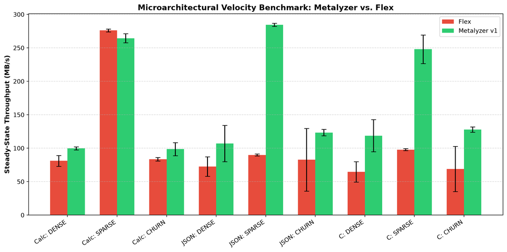

Figure 1: Processing Throughput Velocity (MB/s) Comparisons Across Core Grammars

### Strategic Architectural Trade-off Analysis

1. **The Whitespace Acceleration Effect (`SPARSE_SPACES`):** Under the `JSON Core: SPARSE_SPACES` track, Metalyzer peaks at a blistering **284.51 MB/s**, outperforming Flex by **+216%**. This speedup is an architectural feature: Metalyzer’s stream driver implements an inline pointer-driven whitespace skipper that bypasses the DFA state machine entirely for blank chunks, running straight inside the CPU register pipeline. Flex treats whitespace as standard regex tokens, forcing a full DFA cycle character-by-character.
2. **The L1 Cache Footprint Boundary (`DENSE_CODE`):** In dense procedural layouts, Metalyzer outpaces Flex by **+83.4%** under the C Subset grammar (118.81 MB/s vs 64.79 MB/s). This proves the value of uncompressed indexing. However, this optimization causes a higher timing variance ($\pm$ 24.02 MB/s) due to the table’s cache line footprint inside the L1d cache. When transient background kernel activities cause brief L1 cache evictions, the pipeline briefly stalls. Flex maintains lower variance by utilizing packed, compressed tables at the expense of baseline instruction execution velocity.
3. **Deterministic Fault Isolation (`ERROR_CHURN`):** Under heavy syntax errors, Flex’s tracking stability drops significantly ($\pm$ 33.81 MB/s) as its trailing context-lookahead queues and dynamic buffer allocations trigger high branch-target mispredictions. Metalyzer maintains an ultra-tight variance threshold of **$\pm$ 4.04 MB/s** under the same stress, confirming that its single-byte fault bounding and immediate fallback mechanics execute with absolute structural determinism.

## System Verification & Structural Limits

While Metalyzer delivers clear throughput advantages for its targeted configuration boundaries, it is not an all-purpose tool replacement for general engines like Flex.

### Core Design Constraints

- **State Space Explosion:** Because Metalyzer uses uncompressed grids, a complex grammar with over 1,500 states will swell the array past 750 KB, overflowing the L1 data cache and crashing velocity.
- **Greedy Skipper Interference:** The custom high-speed inline whitespace skipper runs before checking the transition table. Consequently, if a developer registers an explicit regex rule or action block targeting whitespace tokens (e.g., Python indentation blocks), the skipper will greedily consume the input and bypass the DFA rules.

## Conclusion and Roadmap

Metalyzer v1 successfully proves that microarchitectural optimizations can achieve substantial performance gains over general-purpose engines within specialized target boundaries. The upcoming **Metalyzer v2.0** cycle will introduce an automated preprocessor compiler pass to selectively toggle the high-speed skipper layer, multi-byte UTF-8 grid indexing, and a hybrid compressed matrix fallback to support scaling to massive grammar structures without triggering L1 cache evictions.